# COSC-523: Lab 03

**Daniel Carter**

[Notebook Link](https://colab.research.google.com/drive/16KKUbbm_OSo-SFZzMM5w-UuQVhKw0hLt?usp=sharing)

## Getting Started

Follow the instructions below to copy this notebook and to perform some initial setup.

1. Copy this notebook by selecting `File > Save a copy in Drive`.
2. A new window should open for the copied notebook. Move the new notebook to your course folder in Google Drive by selecting `File > Move` and then selecting the desired folder.
3. Update the name of the notebook by removing "Copy of" and replacing "Username" with your actual username.
4. Update the first cell in the notebook by specifying your course number (423 or 523) and by replacing "**Student Name**" with your actual name.
5. Do not edit the line that says `PLACEHOLDER_FOR_NOTEBOOK_LINK`. This will be used by the [Notebook Renderer](https://colab.research.google.com/drive/1CJTipys46ldZxJFwnt7XbdjQUfkmoXeU?usp=sharing) tool to insert a link to your Colab notebook.
6. Enable link sharing for your notebook.

# Part 1: Boundary Extraction

Load the leaf image

Perform boundary extraction

Display the extracted boundary image and original image side by side

```python
#load in all libraries for the lab
import numpy as np
import matplotlib.pyplot as plt
import cv2
from google.colab.patches import cv2_imshow
from PIL import Image, ImageFilter
```

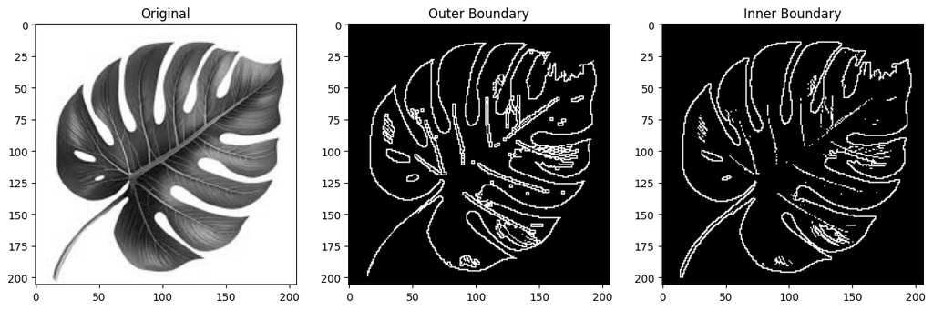

```python
#load in leaf png
leaf = cv2.imread('leaf.png', cv2.IMREAD_GRAYSCALE)

#boundary extraction
#Convert to binary
_, leaf_binary = cv2.threshold(leaf, 127, 255, cv2.THRESH_BINARY)
#Define the kernel
kernel = np.ones((3,3), np.uint8)
#Perform dilation
leaf_dilated = cv2.dilate(leaf_binary, kernel, iterations=1)
#Perform erosion
leaf_eroded = cv2.erode(leaf_binary, kernel, iterations=1)
#Outer Boundary
outer_boundary = cv2.subtract(leaf_dilated, leaf_binary)
#Inner Boundary
inner_boundary = cv2.subtract(leaf_binary, leaf_eroded)

#Plot original, outer, and inner side by side
fig, axs = plt.subplots(1, 3, figsize=(15, 5))
axs[0].imshow(leaf, cmap='gray')
axs[0].set_title('Original')
axs[1].imshow(outer_boundary, cmap='gray')
axs[1].set_title('Outer Boundary')
axs[2].imshow(inner_boundary, cmap='gray')
axs[2].set_title('Inner Boundary')
plt.show()
```

# Part 2: Closing

Load image 2 and perform closing operation, but use PIL library

Display the original and closed image side by side

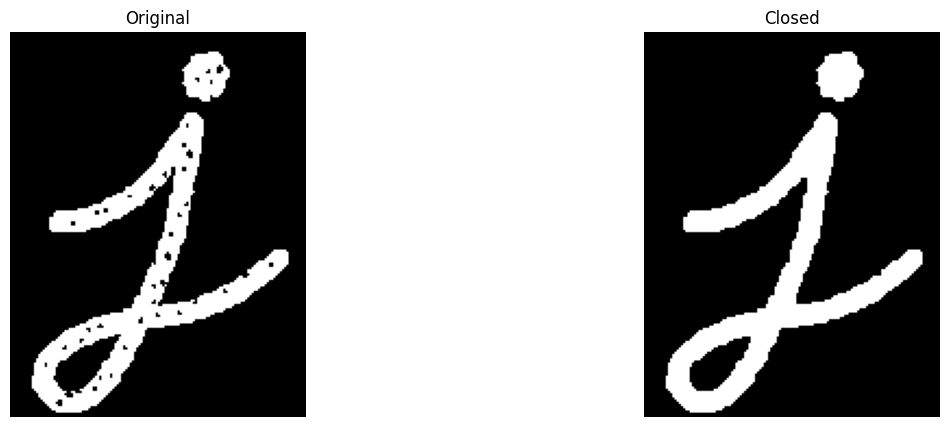

```python
#load image using PIL
image2 = Image.open('image 2.png')
#convert to RGB
image2 = image2.convert('RGB')
#convert to grayscale
image2 = image2.convert('L')
#convert to binary
binary_image2 = image2.point(lambda p:p > 127 and 255)
#convert to numpy array
binary_image2_array = np.array(binary_image2)
#perform closing operation using PIL
#Perform dilation
binary_image2_dilated = Image.fromarray(binary_image2_array).filter(ImageFilter.MaxFilter(3))
binary_image2_dilated = np.array(binary_image2_dilated)
#Perform erosion
binary_image2_eroded = Image.fromarray(binary_image2_dilated).filter(ImageFilter.MinFilter(3))
binary_image2_closed = np.array(binary_image2_eroded)

#Plot original next to closed img
fig, axs = plt.subplots(1, 2, figsize=(15, 5))
axs[0].imshow(binary_image2, cmap='gray')
axs[0].set_title('Original')
axs[1].imshow(binary_image2_closed, cmap='gray')
axs[1].set_title('Closed')
axs[0].axis('off')
axs[1].axis('off')
plt.show()
```

# Part 3: Region Filling 1

Load the gray_coins image and perform region filling on the image

After performing region filling, perform some operation and that leads to coin output image 1

Display both images side by side

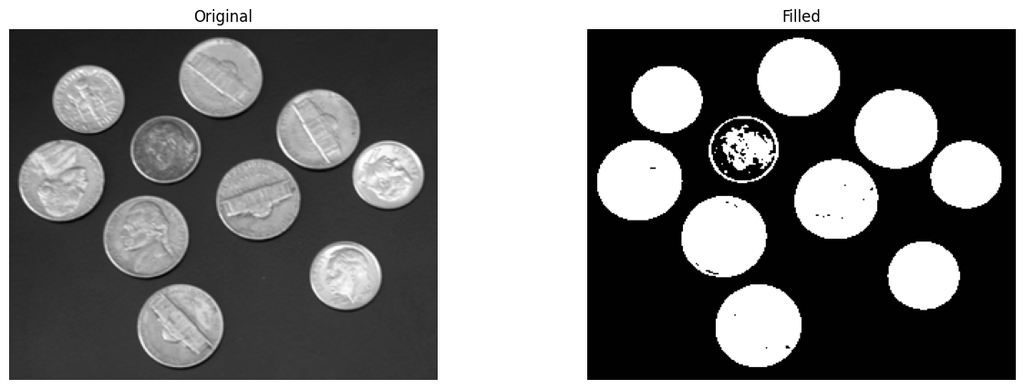

```python
#Read in gray coins png
gray_coins = cv2.imread('gray coins.png', cv2.IMREAD_GRAYSCALE)
#convert to binary
_, gray_coins_binary = cv2.threshold(gray_coins, 127, 255, cv2.THRESH_BINARY)
#Define function similar to the one in the module
def region_filling(image, seed_point):
  h,w = image.shape
  F = np.zeros((h,w), dtype=np.uint8)
  F[seed_point] = 1
  boundary_complement = cv2.bitwise_not(image)
  structuring_element = cv2.getStructuringElement(cv2.MORPH_CROSS, (3,3))
  while True:
    F_dilated = cv2.dilate(F, structuring_element)
    F_new = cv2.bitwise_and(F_dilated, boundary_complement)
    if np.array_equal(F_new, F):
      break
    F = F_new
  filled_image = cv2.bitwise_or(image, F)
  return filled_image

#Perform region filling
filled_image = region_filling(gray_coins_binary, (10,10))

#plot original next to filled
fig, axs = plt.subplots(1, 2, figsize=(15, 5))
axs[0].imshow(gray_coins, cmap='gray')
axs[0].set_title('Original')
axs[1].imshow(filled_image, cmap='gray')
axs[1].set_title('Filled')
axs[0].axis('off')
axs[1].axis('off')
plt.show()
```

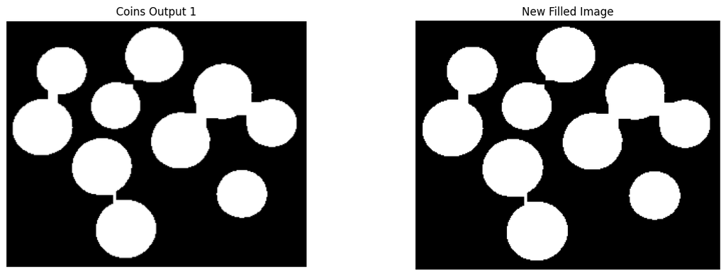

```python
#Perform more cleaning to try to match the coins output 1 that was provided
#load in coins output 1
coins_output_1 = cv2.imread('coin output image1.png', cv2.IMREAD_GRAYSCALE)

#Perform morphological closing to get rid of more of the black
#Started with (3,3) and increased until it matched
kernel = np.ones((9,9), np.uint8)
filled_image_changed = cv2.morphologyEx(filled_image, cv2.MORPH_CLOSE, kernel)

#plot coins output 1 and new filled image
fig, axs = plt.subplots(1,2, figsize=(15,5))
axs[0].imshow(coins_output_1, cmap='gray')
axs[0].set_title('Coins Output 1')
axs[1].imshow(filled_image_changed, cmap='gray')
axs[1].set_title('New Filled Image')
axs[0].axis('off')
axs[1].axis('off')
plt.show()
```